# Random Forest

# About random forest models

Like a bagged tree model, a random forest model includes multiple trees in one model. Unlike a bagged tree, a random forest does not use all available predictors to build each tree. Instead, each tree is built using a few predictors randomly selected from the full set of predictors. Using a different subset of predictors each time means that strong predictors don’t always appear in every tree, and therefore don’t cause all trees to be similar. As a result, individual trees in a random forest are more diverse than in a bagged tree (and their predictions are “de-correlated”), leading to less overall variance in the model and more reliable predictions.

Like a bagged tree model, a bootstrapped sample is drawn from the original data for building each tree in the random forest.

# Data and case weights

All participants included in this analysis had PTA > 25 in the better ear, with complete data across the 28 predictors of interest (n=753). ‘No’ cases were weighted 149/604 = 0.246688 and ‘Yes’ cases were weighted 1.0. In *ranger*, more heavily weighted ‘Yes’ cases will be oversampled in the bootstrap sampling procedure to create a roughly equal number of ‘Yes’ and ‘No’ cases in each bootstrap sample.

# Random forest model

## Number of trees in the forest

Like in a bagged tree model, one parameter to decide on for a random forest is how many trees to include in the model. The default number in R packages is 500, but it just has to be a high enough number that the error rate plateaus. Most gains in accuracy tend to happen within the first 100 trees [(ref)](https://arxiv.org/abs/1804.03515).

The plot below shows that accuracy is low when the number of trees in the forest is too small (5 trees, shown by the light grey line). Accuracy improves from 5 trees to 10, and from 10 trees to 25. Accuracy is highest for 200 trees, though there is overlap of Accuracy SD from 50 to 500 trees, as shown by the shaded regions.

## Number of predictors per tree

One parameter that needs tuning is the number of predictors *m* to select for building each tree in the forest. The default in R is *m = sqrt(p)*, where p is the total number of predictors in the dataset.

The plot below shows that accuracy is generally highest when there are few predictors, e.g. 2 to 4. To increase each predictor’s chance of being used in multiple trees, *m = 4* was chosen, close to the default of *m = sqrt(28) = 5*.

## Minimum node size

The plot below also shows the effect of setting the minimum number of cases in a node before the node is allowed to split further. For a random forest model with 200 trees and *m = 4*, there is almost no variation in accuracy across different node sizes (range 0.8048387 to 0.8059898). To be consistent with the previous classification and bagged tree models, *min.node.size = 20* was chosen.

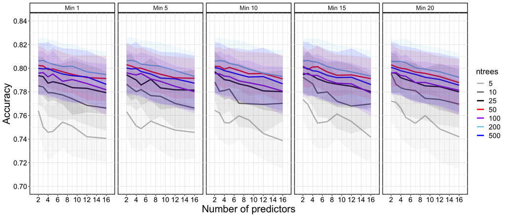

# Model performance

A final random forest model was constructed with 200 unpruned trees, each built from 4 randomly selected predictors, with a minimum node size of 20. The out-of-bag error was 0.244; i.e., the model accuracy was 76% when tested on cases not in the bootstrap sample. The model sensitivity was 34% and the specificity was 86%.

# Variable importance

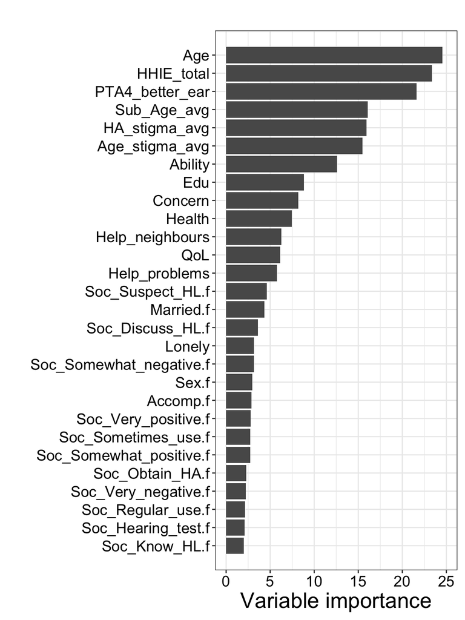

# Takeaways